# Quick Barcode Check

2023-10-04

```r
library(tidyverse)
library(ggside)
library(scales)
library(glue)
library(extraChIPs)
theme_set(
  theme_bw() + theme(plot.title = element_text(hjust = 0.5))
)
```

```r
barcodes <- read_csv(here::here("data/external/barcodes.csv"))
adt_hto <- read_tsv(
  here::here("data/external/adt.tsv"), col_names = c("target", "barcode")
)
```

```r
adt_hto_counts <- here::here("data/fastq/merged/adt_hto_counts.txt.gz") %>%
  read_lines() %>%
  str_trim() %>%
  as_tibble_col() %>%
  separate(value, c("count", "barcode")) %>%
  mutate(count = as.integer(count))

adt_hto_barcode_counts <- here::here("data/fastq/merged/adt_hto_barcode_counts.txt.gz") %>%
  read_lines() %>%
  str_trim() %>%
  as_tibble_col() %>%
  separate(value, c("count", "barcode")) %>%
  mutate(count = as.integer(count))

rnaseq_barcode_counts <- here::here("data/fastq/merged/rnaseq_barcodes.txt.gz") %>%
  read_lines() %>%
  str_trim() %>%
  as_tibble_col() %>%
  separate(value, c("count", "barcode")) %>%
  mutate(count = as.integer(count))
```

## Introduction

Key barcode locations within sequenced libraries

| File | Barcode Type | Barcode Position | UMI Position |
| --- | --- | --- | --- |
| 23-00584_S1_R1_001.fastq.gz | Cell | 1-16 | 17-28 |
| 23-00585_S1_R1_001.fastq.gz | Cell | 1-16 | 17-28 |
| 23-00585_S1_R2_001.fastq.gz | ADT/HTO | 11-25 |  |

- Barcodes were extracted from the raw fastq files using the understood structure of the reads and excluding barcodes with an `N`.
- Barcodes found more than once were counted, whilst singletons were discarded

## ADT/HTO

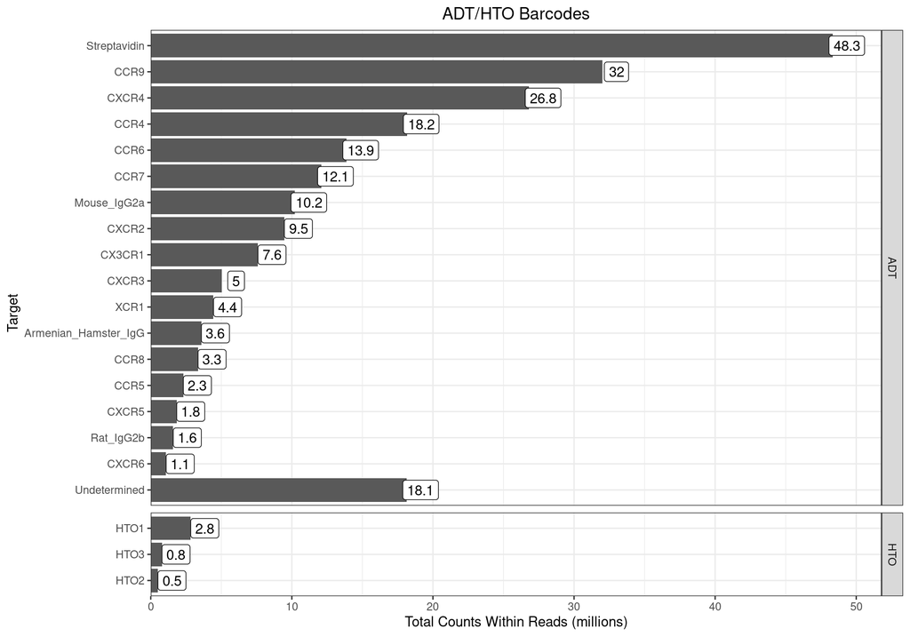

```r
adt_hto_counts %>%
  left_join(adt_hto) %>%
  mutate(
    target = fct_inorder(target) %>%
      fct_na_value_to_level("Undetermined")
  ) %>%
  summarise(
    count = sum(count), .by = target
  ) %>%
  mutate(
    type = case_when(
      target %in% paste0("HTO", 1:3) ~ "HTO",
      TRUE ~ "ADT"
    )
  ) %>%
  ggplot(aes(count / 1e6, fct_rev(target))) +
  geom_col() +
  geom_label(aes(label = round(count / 1e6, 1)), nudge_x = 1) +
  facet_grid(rows = vars(type), scales = "free", space = "free") +
  scale_x_continuous(expand = expansion(c(0, 0.05))) +
  ggtitle("ADT/HTO Barcodes") +
  labs(x = "Total Counts Within Reads (millions)", y = "Target")
```

1,858,271 unique cell barcodes were detected within the ADT/HTO file (23-00585_S1_R1_001.fastq.gz) without filtering beyond counts larger than 1, and exclusion of barcodes containing an `N`. Reducing this to barcodes in more than 1500 reads gave 65,515 barcodes. Notably, no error correction has been performed as these are just taken directly from the reads so this is a crude estimate. No assignment to reads based on the ADT/HTO barcode was performed

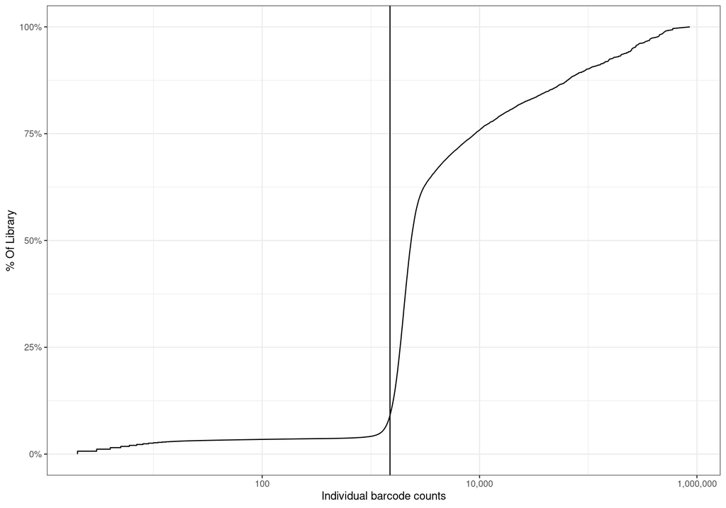

Cumulative proportion of the ADT/HTO sequencing library derived from barcodes arranged in increasing number of reads from which they were derived. Near the 1000 counts threshold, barcodes clearly began to represent the intended signal

```r
adt_hto_barcode_counts %>%
  arrange(count) %>%
  mutate(
    p = count / sum(count), q = cumsum(p)
  ) %>%
  ggplot(aes(count, q)) +
  geom_line() +
  geom_vline(xintercept = 1.5e3) +
  scale_x_log10(labels = comma) +
  scale_y_continuous(labels = percent) +
  labs(
    x = "Individual barcode counts",
    y = "% Of Library"
  )
```

## RNA-Seq

A total of 5,733,529 cell barcodes were detected within the RNA-Seq file (23-00584_S1_R1_001.fastq.gz) without filtering beyond counts larger than 1 and ignoring UMIs. Reducing this to barcodes in more than 900 reads gave 69,545 barcodes. Notably, no error correction has been performed as these are just taken directly from the reads so this is a crude estimate.

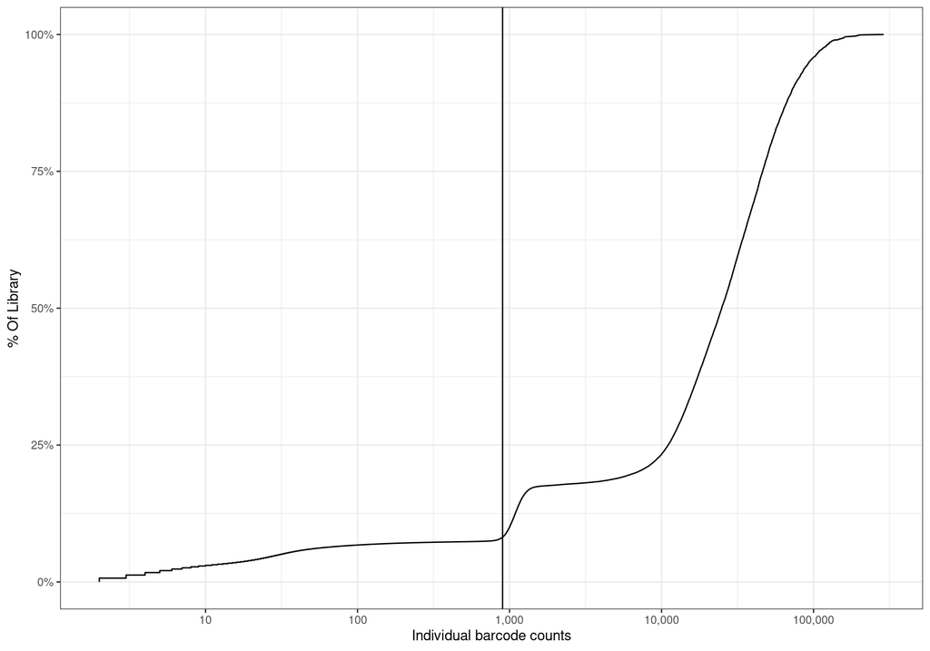

Cumulative proportion of the RNA sequencing library derived from barcodes arranged in increasing number of reads from which they were derived. Near the 1000 counts threshold, barcodes clearly began to represent the intended signal

```r
rnaseq_barcode_counts %>%
  arrange(count) %>%
  mutate(
    p = count / sum(count), q = cumsum(p)
  ) %>%
  ggplot(aes(count, q)) +
  geom_line() +
  geom_vline(xintercept = 900) +
  scale_x_log10(labels = comma) +
  scale_y_continuous(labels = percent) +
  labs(
    x = "Individual barcode counts",
    y = "% Of Library"
  )
```

## Combined Libraries

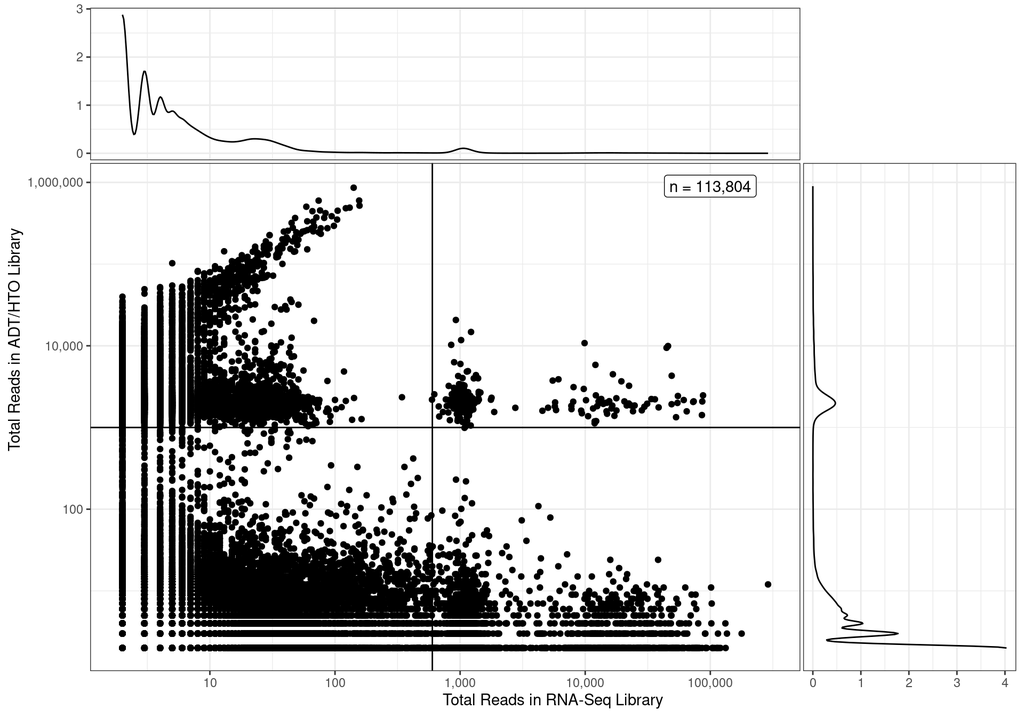

```r
all_barcodes <- rnaseq_barcode_counts %>%
  dplyr::rename(rna_count = count) %>%
  inner_join(
    dplyr::rename(adt_hto_barcode_counts, adt_count = count)
  )
all_barcodes %>%
  ggplot(
    aes(rna_count, adt_count)
  ) +
  geom_point() +
  geom_vline(xintercept = 600) +
  geom_hline(yintercept = 1000) +
  geom_xsidedensity() +
  geom_ysidedensity() +
  annotate(
    "label", x = 1e5, y = 9e5, label = glue("n = {comma(nrow(all_barcodes))}")
  ) +
  scale_xsidey_continuous() +
  scale_ysidex_continuous() +
  scale_x_log10(labels = comma) +
  scale_y_log10(labels = comma) +
  labs(
    x = "Total Reads in RNA-Seq Library",
    y = "Total Reads in ADT/HTO Library",
  ) +
  theme(ggside.panel.scale = 0.3)
```

Total counts for each barcode after joining cell barcodes from the ADT/HTO library and the RNASeq library. For inclusion, barcodes were required to be present in > 1 read in both libraries.

Using the above plot, minimum counts were set at 600 for cell barcodes within the RNA-Seq libraries and 1000 for the ADT/HTO libraries. Applying this criteria gave 261 barcodes passing both. This is clearly an unsatisfactory number of cells identified in both protocols.

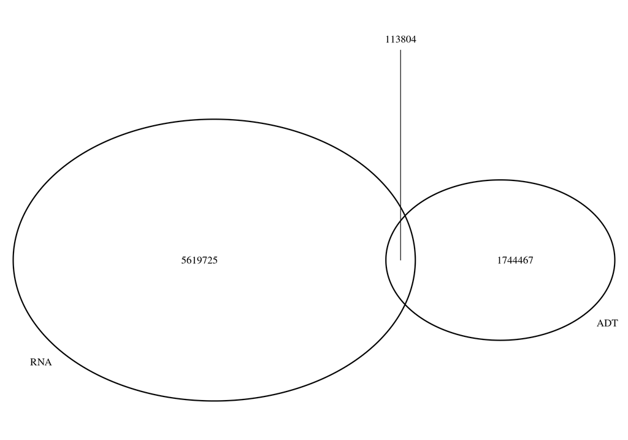

Summary of barcodes found in ADT and RNA-Seq datasets. Barcodes were simply pulled from sequence reads by position, and restricted to those found 2 or more times. No error correction or alignments to libraries was performed

```r
list(
  ADT = adt_hto_barcode_counts,
  RNA = rnaseq_barcode_counts
) %>%
  lapply(pull, "barcode") %>%
  plotOverlaps()
```

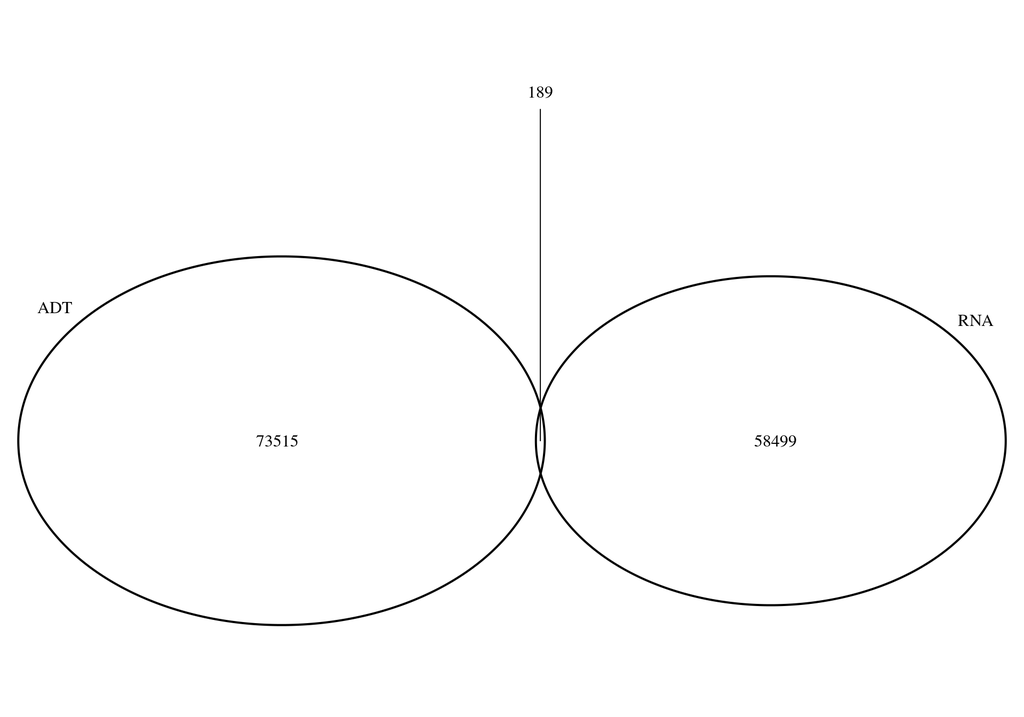

Summary of barcodes found in ADT and RNA-Seq datasets. Barcodes were simply pulled from sequence reads by position, and restricted to those found 1000 or more times. No error correction or alignments to libraries was performed.

```r
list(
  ADT = adt_hto_barcode_counts,
  RNA = rnaseq_barcode_counts
) %>%
  lapply(dplyr::filter, count >= 1000) %>%
  lapply(pull, "barcode") %>%
  plotOverlaps()
```